# Quantitative Text Analysis

Homework 01

Author

Irem Erkilic

## Instructions

- Rename this file to your `2025_qta_lastname_firstname_homework01.qmd` and insert your name at the header of this script under “author” (see `INSERT YOUR NAME`).
- If an answer to a question requires code, add the code in the code block below. For questions that need interpretations or explanations, write your answer in *italics* (using `_` and `_` at the beginning and end of your answer) below the question.
- Please render this file as an .html document and upload the .html document to the assignment folder on Brightspace.
- If the code for one of the questions is not working, leave the code in the chunk, but change the beginning of the chunk to `{r,eval=FALSE}`. Only do this as a last resort, though.

## Questions

**As mentioned previously, StackOverFlow, Google, GitHub Copilot (free subscription for students!) and Chat-GPT are your friends. You are encouraged use these tools to assist you! To understand the advantages and limitations, please write a short summary of your experiences at the end of this document.**

1. By explicitly referring to the literature from the syllabus, list three advantages of dictionaries and three disadvantages of dictionary approaches. You need to mention at least one reading from the syllabus. Suggested length: 100-150 words 3 points

*There are several advantages of dictionary approaches. Firstly, dictionary methods are straightforward to implement and interpret, as they rely on pre-defined lists of terms with assigned values, making them accessible for researchers without advanced computational skills (Grimmer & Stewart, 2013). Also, dictionaries can be tailored to specific domains or research questions, allowing for more precise measurement of relevant concepts, considering that these approaches are computationally efficient and scalable, enabling the analysis of extensive datasets quickly (Proksch et al., 2019).*

*However, dictionaries often fail to account for context, leading to potential misclassification of words with multiple meanings (Grimmer & Stewart, 2013). In addition, pre-defined dictionaries may not capture evolving language use or emerging terms, limiting their applicability in dynamic contexts (Proksch et al., 2019). So, ensuring that dictionary measures accurately capture the intended concepts is difficult and often neglected, undermining reliability (Benoit, 2020; Müller, 2020)*

2. By explicitly referring to the literature from the syllabus and your own views, explain the trade-off between dictionaries with only a few and many terms. You need to mention at least one reading from the syllabus. Suggested length: 100-150 words. 3 points

*Firstly, smaller dictionaries are easier to interpret, as each term’s inclusion is deliberate and tied to specific theoretical constructs whereas larger dictionaries capture more linguistic variation, improving their ability to analyze diverse or complex corpora (Grimmer & Stewart, 2013). In addition, although fewer terms minimize the risk of including irrelevant or ambiguous words that could distort results with more terms, dictionaries are less likely to miss key words in different contexts or evolving language use (Müller, 2020).*

3. Download the `Ireland_Corpus2.0.csv` file from: https://doi.org/10.34894/VKQSPO. Download the PDF file `ReleaseNote_ManifestoVault_Updated.pdf` file to understand the variable codings. Load the data frame into R and transform it into a quanteda corpus. You can use `read.csv()` to load the data frame. Then filter only manifestos **published in 2024**. 5 points

```r
#Load quanteda package
library(quanteda)
#Loading the dataframe
elections_ie_data_frame <- read.csv("Ireland_Corpus2.0.csv")

#Transform it into a quanteda corpus
elections_ie_corpus <- corpus(elections_ie_data_frame, docid_field = "text_id")

#Filter only manifestos published in 2024
elections_ie_data_frame <- read.csv("Ireland_Corpus2.0.csv")
elections_ie_2024 <- subset(elections_ie_data_frame,
                           as.integer(substr(date, 1, 4)) == 2024)

#Turn the filtered data into a quanteda corpus
elections_ie_2024_corpus <- corpus(elections_ie_2024, docid_field = "text_id")

#View the summary of the corpus
summary(elections_ie_2024_corpus)
```

```
Corpus consisting of 17212 documents, showing 100 documents:

             Text Types Tokens Sentences country countryname sentence_id   date
   53110_202411_1     4      4         1      53     Ireland           1 202411
   53110_202411_2    14     14         1      53     Ireland           2 202411
   53110_202411_3    22     26         1      53     Ireland           3 202411
   53110_202411_4    20     23         1      53     Ireland           4 202411
   53110_202411_5    30     38         1      53     Ireland           5 202411
   53110_202411_6    24     27         1      53     Ireland           6 202411
   53110_202411_7     7      7         1      53     Ireland           7 202411
   53110_202411_8    26     30         1      53     Ireland           8 202411
   53110_202411_9    22     25         1      53     Ireland           9 202411
  53110_202411_10    23     23         1      53     Ireland          10 202411
  53110_202411_11     5      5         1      53     Ireland          11 202411
  53110_202411_12     8      8         1      53     Ireland          12 202411
  53110_202411_13     5      5         1      53     Ireland          13 202411
  53110_202411_14     9      9         1      53     Ireland          14 202411
  53110_202411_15    20     20         1      53     Ireland          15 202411
  53110_202411_16     6      6         1      53     Ireland          16 202411
  53110_202411_17    30     35         1      53     Ireland          17 202411
  53110_202411_18    21     22         1      53     Ireland          18 202411
  53110_202411_19    14     15         1      53     Ireland          19 202411
  53110_202411_20     3      3         1      53     Ireland          20 202411
  53110_202411_21    17     19         1      53     Ireland          21 202411
  53110_202411_22    17     17         1      53     Ireland          22 202411
  53110_202411_23    19     19         1      53     Ireland          23 202411
  53110_202411_24    30     35         1      53     Ireland          24 202411
  53110_202411_25    30     32         1      53     Ireland          25 202411
  53110_202411_26    24     25         1      53     Ireland          26 202411
  53110_202411_27    29     32         1      53     Ireland          27 202411
  53110_202411_28    11     11         1      53     Ireland          28 202411
  53110_202411_29    15     17         1      53     Ireland          29 202411
  53110_202411_30    19     23         1      53     Ireland          30 202411
  53110_202411_31    20     23         1      53     Ireland          31 202411
  53110_202411_32    23     25         1      53     Ireland          32 202411
  53110_202411_33    21     23         1      53     Ireland          33 202411
  53110_202411_34     4      4         1      53     Ireland          34 202411
  53110_202411_35    15     15         1      53     Ireland          35 202411
  53110_202411_36    21     23         1      53     Ireland          36 202411
  53110_202411_37    17     17         1      53     Ireland          37 202411
```

[output cut: 149 more lines]

```
 53110    Greens
 53110    Greens
 53110    Greens
 53110    Greens
 53110    Greens
 53110    Greens
 53110    Greens
 53110    Greens
 53110    Greens
 53110    Greens
 53110    Greens
 53110    Greens
 53110    Greens
 53110    Greens
 53110    Greens
```

4. Create a dictionary on terms and phrases related to housing policy. You can use media coverage or official documents (e.g., https://www.gov.ie/en/publication/ef5ec-housing-for-all-a-new-housing-plan-for-ireland/) as a starting point to identify relevant terms for the dictionary. It’s important to avoid false-positive mentions (i.e., content scored as housing even though it could be about a different policy area). 5 points

```r
#Create the dictionary with two key terms
dict_housing <- dictionary(list(
    housing = c("home*", "hous*", "accommodation","buyers"),
    rent = c("rent*", "lease", "landlord", "apartment*", "tenant")

))

#View the dictionary
dict_housing
```

```
Dictionary object with 2 key entries.
- [housing]:
  - home*, hous*, accommodation, buyers
- [rent]:
  - rent*, lease, landlord, apartment*, tenant
```

5. Get the number of sentences per manifesto (either using `group_by` in combination with `count()` or `table()`). Which manifesto has the highest/lowest number of sentences? 4 points

```r
# Load dplyr library
library(dplyr)
# Create a new variable 'manifesto_id' by removing the final underscore and characters
elections_ie_2024$manifesto_id <- sub("_\\d+$", "", elections_ie_2024$text_id)

# Count the number of sentences per manifesto
sentence_counts <- elections_ie_2024 %>%
  group_by(manifesto_id) %>%
  count(name = "sentence_count")

# Find the manifesto with the highest number of sentences
max_sentences <- sentence_counts %>%
  filter(sentence_count == max(sentence_count))

# Find the manifesto with the lowest number of sentences
min_sentences <- sentence_counts %>%
  filter(sentence_count == min(sentence_count))

# Display results
print("Manifesto with the highest number of sentences:")
```

```
[1] "Manifesto with the highest number of sentences:"
```

```r
print(max_sentences)
```

```
# A tibble: 9 × 2
# Groups:   manifesto_id [9]
  manifesto_id sentence_count
  <chr>                 <int>
1 53110_202411           1588
2 53231_202411            799
3 53320_202411           3062
4 53321_202411           2953
5 53520_202411           2607
6 53620_202411           1923
7 53621_202411            472
8 53951_202411           2307
9 53952_202411           1501
```

```r
print("Manifesto with the lowest number of sentences:")
```

```
[1] "Manifesto with the lowest number of sentences:"
```

```r
print(min_sentences)
```

```
# A tibble: 9 × 2
# Groups:   manifesto_id [9]
  manifesto_id sentence_count
  <chr>                 <int>
1 53110_202411           1588
2 53231_202411            799
3 53320_202411           3062
4 53321_202411           2953
5 53520_202411           2607
6 53620_202411           1923
7 53621_202411            472
8 53951_202411           2307
9 53952_202411           1501
```

6. Tokenize the corpus without any preprocessing. Store the output as a new object called “toks_noprocessing”. 3 points

```r
#Tokenise the corpus
toks_noprocessing <- tokens(elections_ie_2024_corpus)

#Display the result
toks_noprocessing
```

```
Tokens consisting of 17,212 documents and 6 docvars.
53110_202411_1 :
[1] "More"   "and"    "Better" "Homes"

53110_202411_2 :
 [1] "Too"          "many"         "people"       "are"          "still"
 [6] "struggling"   "with"         "the"          "cost"         "and"
[11] "availability" "of"
[ ... and 2 more ]

53110_202411_3 :
 [1] "Rents"         "remain"        "too"           "high"
 [5] ","             "homeownership" "is"            "still"
 [9] "out"           "of"            "reach"         "for"
[ ... and 14 more ]

53110_202411_4 :
 [1] "But"      "there"    "have"     "been"     "positive" "changes"
 [7] "in"       "recent"   "years"    "–"        "changes"  "which"
[ ... and 11 more ]

53110_202411_5 :
 [1] "These"        "reforms"      ","            "such"         "as"
 [6] "the"          "introduction" "of"           "cost"         "rental"
[11] "housing"      ","
[ ... and 26 more ]

53110_202411_6 :
 [1] "Our"         "insistence"  "on"          "abolishing"  "the"
 [6] "Strategic"   "Housing"     "Development" "process"     ","
[11] "co-living"   ","
[ ... and 15 more ]

[ reached max_ndoc ... 17,206 more documents ]
```

7. Apply the dictionary you created above to the tokens object of Irish party manifestos, then create a dfm. 5 points

```r
#Create a dfm from the tokens object
dfm_all <- dfm(toks_noprocessing)

#Apply the dictionary by looking up its terms in the dfm
dfm_housing <- dfm_lookup(dfm_all, dictionary = dict_housing)

#Print the resulting dfm
print(dfm_housing)
```

```
Document-feature matrix of: 17,212 documents, 2 features (94.77% sparse) and 6 docvars.
                features
docs             housing rent
  53110_202411_1       1    0
  53110_202411_2       1    0
  53110_202411_3       2    1
  53110_202411_4       0    0
  53110_202411_5       2    1
  53110_202411_6       2    0
[ reached max_ndoc ... 17,206 more documents ]
```

8. Apply Boolean weighting to the dfm. Note: check out `dfm_weight()`. This will tell you whether a sentence relates to housing or not (according to the dictionary). Then transform the dfm object to a data frame using `convert()`. 5 points

```r
#Apply Boolean weighting
dfm_housing_boolean <- dfm_weight(dfm_housing, scheme = "boolean")

#Transform the weighted dfm to a data frame
housing_df <- convert(dfm_housing_boolean, to = "data.frame")

#Preview the resulting data frame
head(housing_df)
```

```
          doc_id housing rent
1 53110_202411_1       1    0
2 53110_202411_2       1    0
3 53110_202411_3       1    1
4 53110_202411_4       0    0
5 53110_202411_5       1    1
6 53110_202411_6       1    0
```

9. Create a ggplot2 plot with the housing average on the x-axis and the partynames on the y-axis. Interpret the output: which parties focus most on housing? In all plots, make sure to add meaningful/readable axis labels. Change the ggplot2 theme to theme_bw(). 5 points

```r
# Loading the necessary library
#library(ggplot2)

# Add a document identifier
#housing_df$doc_id <- docnames(dfm_housing_boolean)

# Load the new data including two columns
#new_data <- elections_ie_2024[, c("text_id", "partyname")]

# Merge the housing data with the metadata using the document id
#merged_df <- merge(housing_df, new_data, by.x = "doc_id", by.y = "text_id")

# Compute the average Boolean housing indicator per party.
#party_housing_avg <- merged_df %>%
  #group_by(partyname) %>%
  #summarise(housing_avg = mean(housing))

# Create the ggplot with housing average on the x-axis and party names on the y-axis
#housing_plot <- ggplot(party_housing_avg, aes(x = housing_avg, y = reorder(partyname, housing_avg))) +
  #geom_point(size = 3) +
  #theme_bw() +
  #labs(x = "Housing Average",
       #y = "Party Name",
       #title = "Average Housing Presence by Party")

# Display the plot
#print(housing_plot)

# It is somehow giving a blank plot. I couldn't solve the issue.
```

10. Create a faceted **ggplot2** plot (`facet_wrap()`) with the party name on top of each box/facet, the housing average on the x-axis, and the year on the y-axis. Interpret the output: which parties focus most on housing? In all plots, make sure to add meaningful/readable axis labels. Change the ggplot2 theme to `theme_bw()`. 5 points

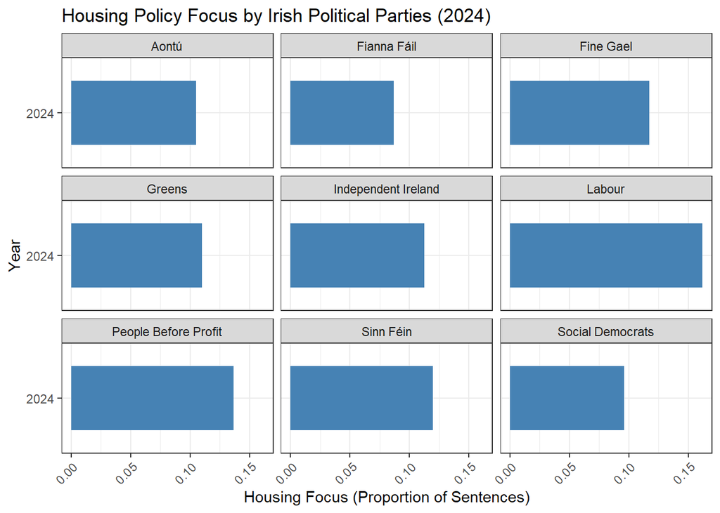

```r
#Load required libraries
library(dplyr)
library(ggplot2)


#Merge metadata with housing indicators
housing_df <- convert(dfm_housing, to = "data.frame")
housing_df$doc_id <- docnames(dfm_housing)  # Correct document IDs
merged_df <- merge(housing_df, elections_ie_2024[, c("text_id", "partyname", "date")],
                   by.x = "doc_id", by.y = "text_id")

#Calculate yearly housing averages per party
merged_df$year <- as.integer(substr(merged_df$date, 1, 4))
party_housing_avg <- merged_df %>%
  group_by(partyname, year) %>%
  summarise(housing_avg = mean(housing, na.rm = TRUE)) %>%
  ungroup()
#Create faceted plot
ggplot(party_housing_avg, aes(x = housing_avg, y = as.factor(year))) +
  geom_col(fill = "steelblue", width = 0.7) +
  facet_wrap(~ partyname, ncol = 3) +
  theme_bw() +
  labs(x = "Housing Focus (Proportion of Sentences)",
       y = "Year",
       title = "Housing Policy Focus by Irish Political Parties (2024)") +
  theme(axis.text.x = element_text(angle = 45, hjust = 1))
```

11. Apply the Lexicoder Sentiment Dictionary (`data_dictionary_LSD2015`, included in **quanteda**) to the sentence-level party manifestos (toks_noprocessing). You can use the tokens object you created above (that you created before applying a dictionary). Create a dfm and convert this dfm into a data frame. Use the formula suggested by Proksch et al. (2019, Legislative Studies Quarterly) and calculate a sentiment score for each sentence. This formula was also listed in the slides for week 4. 10 points

```r
#Load Lexicoder Sentiment Dictionary (LSD2015)
data("data_dictionary_LSD2015")

# Apply dictionary to tokenized sentences
dfm_sentiment <- dfm_lookup(dfm(toks_noprocessing), dictionary = data_dictionary_LSD2015)

#Convert dfm to data frame
df_sentiment <- convert(dfm_sentiment, to = "data.frame")

#Calculate sentiment score using the correct Proksch et al. (2019) formula
df_sentiment <- df_sentiment %>%
  mutate(total_words = rowSums(select(., -doc_id)),  # Sum all word counts per sentence
         sentiment_score = (positive - negative) / total_words)

#Print the first few rows
head(df_sentiment)
```

```
          doc_id negative positive neg_positive neg_negative total_words
1 53110_202411_1        0        1            0            0           1
2 53110_202411_2        2        0            0            0           2
3 53110_202411_3        3        1            0            0           4
4 53110_202411_4        0        2            0            0           2
5 53110_202411_5        2        1            0            0           3
6 53110_202411_6        1        1            0            0           2
  sentiment_score
1       1.0000000
2      -1.0000000
3      -0.5000000
4       1.0000000
5      -0.3333333
6       0.0000000
```

12. Merge the data frame from the previous question with the data frame created in question 8. You can use the `left_join()` function from the **dplyr** package. 5 points

```r
#Merge df_sentiment with housing_df
merged_df <- left_join(df_sentiment, housing_df, by = "doc_id")

#Check the first few rows
head(merged_df)
```

```
          doc_id negative positive neg_positive neg_negative total_words
1 53110_202411_1        0        1            0            0           1
2 53110_202411_2        2        0            0            0           2
3 53110_202411_3        3        1            0            0           4
4 53110_202411_4        0        2            0            0           2
5 53110_202411_5        2        1            0            0           3
6 53110_202411_6        1        1            0            0           2
  sentiment_score housing rent
1       1.0000000       1    0
2      -1.0000000       1    0
3      -0.5000000       2    1
4       1.0000000       0    0
5      -0.3333333       2    1
6       0.0000000       2    0
```

13. Transform the binary indicator of housing (1/0) into a factor variable – call it housing_factor – taking the value “Housing” when the variable takes the value 1 and “Other Policy Area” if the value is 0. Run a linear regression model using the `lm()` function and predict the sentence-level sentiment score. The independent variable should be housing_factor. Add a control variable for the manifesto (=manifesto fixed effects). 5 points

```r
#Convert binary housing indicator to a factor
merged_df <- merged_df %>%
  mutate(housing_factor = factor(housing, levels = c(0, 1), labels = c("Other Policy Area", "Housing")))

#Run the regression model with total_words and housing_factor as predictors
model <- lm(sentiment_score ~ housing_factor + total_words, data = merged_df)

#Show results
summary(model)
```

```
Call:
lm(formula = sentiment_score ~ housing_factor + total_words,
    data = merged_df)

Residuals:
    Min      1Q  Median      3Q     Max
-1.4395 -0.4036  0.5874  0.6143  0.6298

Coefficients:
                       Estimate Std. Error t value Pr(>|t|)
(Intercept)            0.367763   0.012537  29.335   <2e-16 ***
housing_factorHousing -0.006527   0.025491  -0.256   0.7979
total_words            0.008967   0.004140   2.166   0.0303 *
---
Signif. codes:  0 '***' 0.001 '**' 0.01 '*' 0.05 '.' 0.1 ' ' 1

Residual standard error: 0.7607 on 12527 degrees of freedom
  (4682 observations deleted due to missingness)
Multiple R-squared:  0.0003805, Adjusted R-squared:  0.0002209
F-statistic: 2.384 on 2 and 12527 DF,  p-value: 0.09219
```

14. Interpret the output of the regression model. Is sentiment in housing-related statements more positive or negative than in other statements? Suggested length: around 100 words; 1 point

*The regression model shows that the sentiment in housing-related statements is not significantly different from that in other policy areas. The coefficient for housing_factorHousing is -0.0065 with a p-value of 0.7979, indicating no statistically significant difference in sentiment between “Housing” and “Other Policy Area.” Additionally, the number of words (total_words) has a positive and statistically significant effect on sentiment, with each additional word increasing the sentiment score slightly. However, the model explains very little of the variation in sentiment (R-squared = 0.00038), suggesting that other factors may also influence sentiment.*

15. Use `tokens_keep()` to select only negative terms from “toks_noprocessing” (`data_dictionary_LS2015$negative`). Then transform the object to a dfm and get the 100 most frequent negative terms. Are there features which might not be negative in this context? Indicate a few terms. Repeat the same for positive terms. 5 points

*Firstly, it seems like the words “ireland” and “ireland’s” are not necessarily negative. Also, the word “too” may not indicate a negative sentiment contextually. Moreover, the word “unprecedented” has potential to be used with positive sentences.* *Secondly, the word “neutrality” is classified as a positive term, which may not make sense when considering the word itself. In addition, the word “support” could be used in a negative sentence such as ‘lack of support’, which may indicate a negative address.*

```r
#Filter negative terms
negative_tokens <- tokens_keep(toks_noprocessing, pattern = data_dictionary_LSD2015$negative)

#Transform tokens to dfm
negative_dfm <- dfm(negative_tokens)

#Get the 100 most frequent negative terms
top_negative_terms <- topfeatures(negative_dfm, 100)

#Print the most frequent negative terms
print(top_negative_terms)
```

```
           ireland          ireland’s         disability            poverty
              1121                366                259                180
      disabilities             crisis            against         challenges
               172                152                134                131
             crime                too              waste           violence
               105                104                102                101
         emergency           critical           criminal               risk
                95                 92                 88                 86
        vulnerable           disabled            victims          oversight
                75                 73                 71                 68
             abuse       homelessness               lack             cancer
                66                 62                 61                 61
            double             prison            charges            illegal
                60                 58                 52                 51
           abolish             failed              limit     discrimination
                51                 50                 47                 45
               war            failure       disadvantage           conflict
                45                 43                 42                 40
            oppose             damage               loss             burden
                40                 38                 37                 37
         addiction           homeless      disadvantaged             forced
                37                 36                 36                 36
              poor           affected             limits          pollution
                36                 34                 33                 33
            delays             combat          challenge              avoid
                33                 33                 32                 32
            crimes            threats         inequality        deprivation
                31                 31                 31                 31
           problem           problems             charge          penalties
                30                 28                 28                 28
          dementia              risks            limited          difficult
                27                 26                 26                 25
         exclusion         artificial           shortage               hate
                25                 24                 24                 24
             fraud         struggling          eliminate         wastewater
                24                 23                 23                 23
         suffering             threat              fight          defective
                23                 23                 23                 22
     unprecedented           invasion          shortages           negative
                22                 21                 21                 21
      exploitation          excessive         abolishing             severe
                21                 21                 20                 20
           cutting             deaths            deficit          dangerous
                20                 20                 20                 20
          excluded            extreme               debt         precarious
                19                 19                 19                 19
disproportionately       difficulties             racism            harmful
                19                 18                 18                 18
           disease          disregard           struggle              worst
                18                 18                 18                 18
```

```r
#Filter positive terms
positive_tokens <- tokens_keep(toks_noprocessing, pattern = data_dictionary_LSD2015$positive)

#Transform tokens to dfm
positive_dfm <- dfm(positive_tokens)

#Get the 100 most frequent positive terms
top_positive_terms <- topfeatures(positive_dfm, 100)

#Print the most frequent positive terms
print(top_positive_terms)
```

```
        ensure        support           care        provide       ensuring
          1383           1321            701            694            372
      supports         rights        improve    sustainable         create
           333            320            318            269            266
          free     supporting     affordable         better      resources
           250            246            235            234            233
       enhance     protection          right  accommodation        protect
           226            224            214            202            198
          help        quality      providing        benefit         safety
           197            189            173            172            165
     dedicated           like  opportunities     strengthen    significant
           163            161            161            157            156
       special      essential      encourage           fair           well
           154            145            140            140            136
 comprehensive     accessible           best         credit          vital
           130            125            124            124            119
      equality           safe         secure       progress        achieve
           118            115            115            115            115
     improving         strong     innovation       benefits           good
           112            112            109            106             98
accountability    educational     commitment      effective responsibility
            97             97             93             90             90
      creating         active       learning      supported          civil
            89             87             84             83             80
          open            aid sustainability         wealth      voluntary
            78             77             75             75             74
    protecting       stronger         foster        efforts     assistance
            73             73             73             68             66
       restore      agreement       improved       adequate       properly
            66             66             66             65             65
   restoration     neutrality         vision     efficiency      enhancing
            64             64             62             62             62
      enhanced     adequately      protected        advance         relief
            61             59             57             55             55
  contribution     successful       relevant  contributions       positive
            55             53             53             53             52
   responsible        credits         assist       advocate    effectively
            51             51             51             50             50
     efficient        forward        balance     incentives         robust
            50             50             49             49             49
```

16. Remove the terms that, in your opinion, do not express positive or negative sentiment from the “toks_noprocessing” tokens object (using `tokens_remove()`), apply the dictionary again, and repeat the steps from questions 11 to 13. Does the inclusion or exclusion of these terms affect the substantive conclusions you can draw from the linear regression model? Suggested length: 50-100 words; 5 points

*By removing terms like “Ireland” and “too”, which might not express sentiment in certain contexts, the model could become more accurate in measuring the sentiment of statements. These words may have inflated or skewed the sentiment score, particularly in cases where they are part of neutral or non-sentimental phrases. If these terms appeared frequently in certain manifestos or political contexts, removing them could potentially lead to more accurate sentiment scores, resulting in more meaningful conclusions from the regression model.*

```r
#Terms to remove that do not express sentiment
terms_to_remove <- c("ireland", "ireland’s", "too", "unprecedented", "neutrality", "support")

#Remove these terms from the tokens object
toks_cleaned <- tokens_remove(toks_noprocessing, pattern = terms_to_remove)

#Apply Lexicoder Sentiment Dictionary (Negative and Positive terms)
negative_tokens_cleaned <- tokens_keep(toks_cleaned, pattern = data_dictionary_LSD2015$negative)
positive_tokens_cleaned <- tokens_keep(toks_cleaned, pattern = data_dictionary_LSD2015$positive)

#Create dfm for cleaned tokens
negative_dfm_cleaned <- dfm(negative_tokens_cleaned)
positive_dfm_cleaned <- dfm(positive_tokens_cleaned)

#Calculate sentiment score
sentiment_df_cleaned <- data.frame(
  doc_id = docnames(negative_dfm_cleaned),
  negative = rowSums(negative_dfm_cleaned),
  positive = rowSums(positive_dfm_cleaned)
)

#Ensure that the sentiment_score is calculated properly
sentiment_df_cleaned <- sentiment_df_cleaned %>%
  mutate(total_words = rowSums(select(., -doc_id)),  # Sum all word counts per sentence
         sentiment_score = (positive - negative) / total_words)

#Merge sentiment data with the original data frame
merged_cleaned_df <- left_join(merged_df, sentiment_df_cleaned, by = "doc_id")

#I had to delete the regression code
#(model_cleaned <- lm(sentiment_score ~ housing_factor + total_words, data = merged_cleaned_df))
#Because it halts the html rendering.
```

17. Describe three advantages of supervised machine learning approaches or fine-tuned transformer sentiment models compared to the dictionary approach? Suggested length: 100 words; 3 points

*Supervised machine learning approaches or fine-tuned transformer models can capture the context of words, understanding how sentiment may change based on surrounding text, whereas dictionary-based approaches may misinterpret sentiment due to their reliance on predefined lists of words as we have observed the questions above. Also, fine-tuned transformers can achieve higher accuracy by learning nuanced sentiment patterns directly from labeled data, whereas dictionary-based methods may oversimplify sentiment by only relying on word presence without considering the full sentence structure.*

## Keyness analysis

18. Create a new document-level variable that takes the values “FF/FG” for Fianna Fáil and Fine Gael manifestos, and the value “Other Parties” for all other manifestos. Tokenize this text corpus. Then create a dfm, and group this dfm by the new document-level variable (ffg_other). 10 points

```r
#Create the new variable ffg_other based on the party
elections_ie_2024 <- elections_ie_2024 %>%
  mutate(ffg_other = case_when(
    partyname %in% c("Fianna Fáil", "Fine Gael") ~ "FF/FG",
    TRUE ~ "Other Parties"
  ))

#Filter the 2024 election manifestos and create a corpus
corpus_ie_2024 <- corpus(elections_ie_2024)

#Tokenize the corpus and create a dfm
tokens_ie_2024 <- tokens(corpus_ie_2024)

#Create a dfm grouped by the new document-level variable ffg_other
dfm_ie_2024 <- dfm(tokens_ie_2024)

#Add the 'ffg_other' grouping to the dfm as a document-level variable
dfm_grouped <- dfm_group(dfm_ie_2024, groups = elections_ie_2024$ffg_other)

#View the dfm grouped by ffg_other
print(dfm_grouped)
```

```
Document-feature matrix of: 2 documents, 13,315 features (30.82% sparse) and 4 docvars.
               features
docs            more   and better homes too many people  are still struggling
  FF/FG          272  3557     71    92   8   21    213  299     5          0
  Other Parties  664 10484    163   289  96  275    871 1477    67         23
[ reached max_nfeat ... 13,305 more features ]
```

19. Run a keyness analysis using the textstat_keyness() function from the **quanteda.textstsats** package on this grouped dfm. 6 points

```r
#Load the quanteda.textstats package
library(quanteda.textstats)
#Run keyness analysis on the grouped dfm
keyness_results <- textstat_keyness(dfm_grouped)

#View the results, too long, use head()
head(keyness_results)
```

```
  feature      chi2 p n_target n_reference
1       : 2290.1059 0     1620         717
2    fine 1149.9464 0      482          51
3    gael 1036.6528 0      429          42
4  fianna  677.5264 0      295          38
5    fáil  669.3077 0      288          35
6    will  369.6878 0     1572        2429
```

20. Use the `textplot_keyness()` functions from **quanteda.textplots** and show differences in word usage between Fianna Fáil/Fine Gael and all other parties. Plot 20 words for each group. 6 points

```r
#Load quanteda.textplots
library(quanteda.textplots)
#Display the top 20 significant words for Fianna Fáil/Fine Gael (FF/FG) vs. Other Parties
top_keyness <- keyness_results %>%
  arrange(desc(chi2)) %>%
  head(20)

# View the top 20 keyness results
print(top_keyness)
```

```
       feature      chi2 p n_target n_reference
1            : 2290.1059 0     1620         717
2         fine 1149.9464 0      482          51
3         gael 1036.6528 0      429          42
4       fianna  677.5264 0      295          38
5         fáil  669.3077 0      288          35
6         will  369.6878 0     1572        2429
7     returned  344.5938 0      137          10
8      enhance  343.2515 0      181          45
9           we  268.5693 0     1222        1929
10 initiatives  216.8076 0      131          44
11     support  216.3909 0      578         743
12   committed  183.6043 0      155          86
13      gael’s  138.4987 0       52           2
14    ensuring  137.4601 0      196         176
15        2020  120.2401 0       67          19
16          if  116.2878 0      148         122
17   enhancing  113.8470 0       53           9
18    continue  112.5902 0      182         178
19 individuals  102.3611 0       78          38
20   ireland’s  101.9918 0      180         186
```

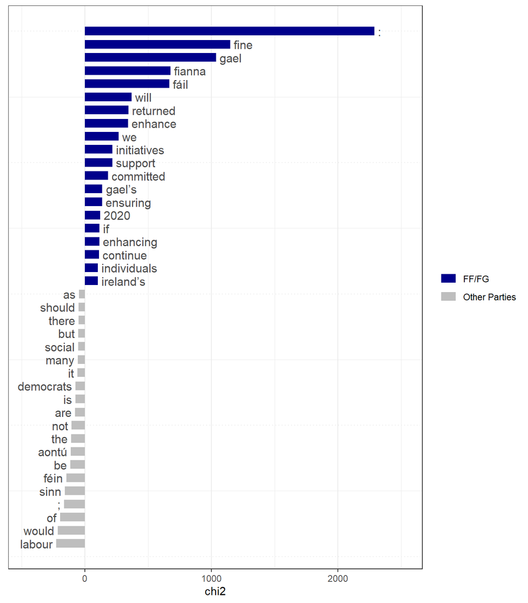

```r
#Plot the keyness analysis for top 20 words
textplot_keyness(keyness_results, n = 20)
```

## BONUS: Thinking about the Final Research Paper

18. **BONUS**: Let’s think about your final research paper: outline a testable research question you would address using quantitative text analysis. What is the dependent variable, and how could it be measured? Suggested length: 100 words; 1 bonus point

*I am planning to write my dissertation on a comparison between two statistical institutions: one of them is an EU member-state institution (possibly D-Statis) and TurkStat (Türkiye’s national statistical institution). This comparison will focus on the methodology and new technologies that is used by D-Statis, also how aligned it is with EU regulations on official statistical production comparing TurkStat’s alignment with the EU as well. I am a Jean Monnet scholar (https://www.cfcu.gov.tr/jean-monnet-scholarship-programme) in Statistics field, that’s why I will be conducting this research. I am planning to focus on asylum-seeker statistics. As you may guess, public trust to the official statistics is an interesting topic to study on and text analysis may be a useful method to retrieve necessary data from relevant media. So, for this module, I am planning to conduct a brief research for the public trust towards official asylum-seeker statistics that is produced by a national statistical institution. My possible research question may be “How does public discourse in media reflect trust in official asylum-seeker statistics produced by TurkStat, compared to D-Statis, in alignment with EU regulations?” The dependent variable in this case is public trust, which could be measured through sentiment analysis of media texts discussing asylum-seeker statistics. By examining positive, negative, and neutral sentiment in media reports, you can quantify the level of trust, providing insights into how public opinion is shaped by statistical institutions’ methodologies and alignment with EU standards.*

19. **BONUS**: Which methodological approach could be suitable to test this research question? Relate to literature from the syllabus we have discussed so far or literature to be discussed in the coming weeks. Suggested length: 50-100 words; 1 bonus point

I encourage you to use AI tools to support you with coding. Please write down for which question(s) AI tools were particularly helpful, and for which questions it was very not helpful. Your responses to this question will not affect your grade.

*I have used Perplexity.ai and ChatGPT to find some possible solutions to the errors that I got while coding. To start with, in Question 9, I have used AI to compute the average Boolean housing indicator (I am bad at maths). Secondly, I wondered why the output had zero sentiment scores for all sentences in Question 11 and asked ChatGPT, got a reasonable answer. In Question 16, even though the regression code worked and I could see the output in the terminal, I couldn’t render it for some reason. I asked ChatGPT and it recommended me to use a sample from the data and run a regression on it, which did not work either. So, I had to remove the regression code line to be able to render the file. I also used Perplexity.ai to summarise and shorten my findings in the first two questions. Overall, AI helped me making some errands easier and giving some basic answers to my questions those are often caused by my lack of knowledge in R.*